# Project #2

Group Members: Ashley King, Peter Gray

May-03-2020

## a) First candidate model (Model we arrived at in the last project)

```r
housing <- read_excel("Housing.xlsx")

model_one <-lm(price ~ poly(bath,3) + lot + garagesize, data = housing)
summary(model_one)
```

```
##
## Call:
## lm(formula = price ~ poly(bath, 3) + lot + garagesize, data = housing)
##
## Residuals:
##     Min      1Q  Median      3Q     Max
## -89.034 -33.959  -2.748  31.083 126.151
##
## Coefficients:
##                Estimate Std. Error t value Pr(>|t|)
## (Intercept)     211.365     18.892  11.188  < 2e-16 ***
## poly(bath, 3)1   85.323     55.530   1.537  0.12892
## poly(bath, 3)2  163.798     53.197   3.079  0.00297 **
## poly(bath, 3)3   61.877     55.232   1.120  0.26641
## lot               9.889      4.094   2.415  0.01833 *
## garagesize       22.355      8.427   2.653  0.00987 **
## ---
## Signif. codes:  0 '***' 0.001 '**' 0.01 '*' 0.05 '.' 0.1 ' ' 1
##
## Residual standard error: 52.82 on 70 degrees of freedom
## Multiple R-squared:  0.2845, Adjusted R-squared:  0.2334
## F-statistic: 5.568 on 5 and 70 DF,  p-value: 0.0002246
```

- The model that we ended up with had a multiple R squared value of 0.2845 (not too good)
- It had a good F-statistic, but not great.
- This model also had a very decent p-value. With all of this it explained less than 1/3 of any variation, but what variation it can explain, is very likely to be correct.

## b) Creating our second candidate model using regsubsets.

We decided to use backwards selection because we wanted to remove the worse predictors first. This method also avoids the suppresion affect of a single predictor.

### Using backwards selection

```r
regfit_backwards <- regsubsets(price ~ size + lot + bath + bedrooms + agestandardized + garagesize + status + elem, data = housing, nvmax = 14, method = "backward")

reg.summary <- summary(regfit_backwards)
```

### Determining the number of variables

To determine the number of variables, we have plotted the output statistics for each number of variables. Thus we can see how many variables is best for each statistic.

```r
par(mfrow=c(2,2))
plot(reg.summary$rsq,xlab="Number of Variables",ylab="R-squared",type="l")
which.max(reg.summary$rsq)
```

```
## [1] 13
```

```r
plot(reg.summary$adjr2,xlab="Number of Variables",ylab="Adjusted RSq",type="l")
which.max(reg.summary$adjr2)
```

```
## [1] 9
```

```r
points(9,reg.summary$adjr2[9], col="red",cex=2,pch=20)
plot(reg.summary$cp,xlab="Number of Variables",ylab="Cp",type='l')
which.min(reg.summary$cp)
```

```
## [1] 6
```

```r
points(6,reg.summary$cp[6],col="red",cex=2,pch=20)
which.min(reg.summary$bic)
```

```
## [1] 6
```

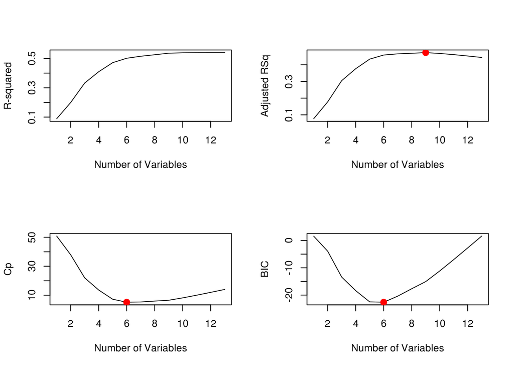

```r
plot(reg.summary$bic,xlab="Number of Variables",ylab="BIC",type='l')
points(6,reg.summary$bic[6],col="red",cex=2,pch=20)
```

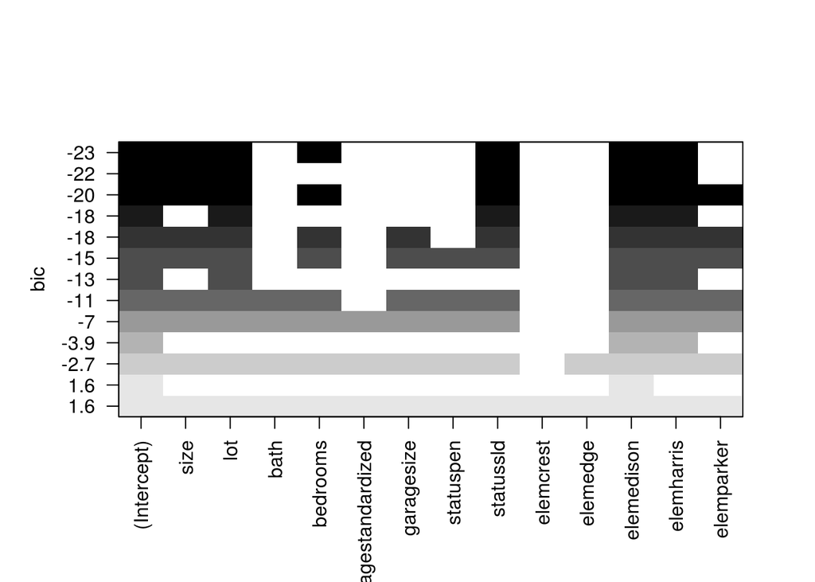

```r
plot(regfit_backwards)
```